# Внешний курс. Блок 2. Защита ПК/телефона

Основы информационной безопасности

Мурашов И. В., НКАбд-03-23

Российский университет дружбы народов, Москва, Россия

17 мая 2025

## Докладчик

- Мурашов Иван Вячеславович
- Cтудент, 2 курс, группа НКАбд-03-23
- Российский университет дружбы народов
- 1132236018@rudn.ru
- https://neve7mind.github.io

## Цель работы

Выполнение контрольных заданий 2го блока внешнего курса “Основы Кибербезопасности”.

## Шифрование диска

Шифрование диска - технология защиты информации, которая переводит данные на диске в нечитаемый код. Само собой можно зашифровать загрузочный сектор диска.

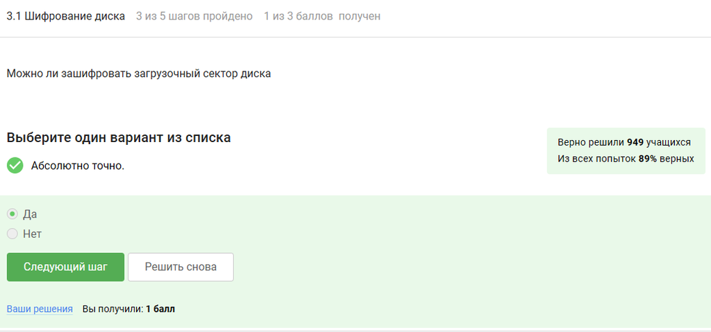

Вопрос 3.1.1

## Шифрование диска

Шифрование диска основано на симметричном шифровании.

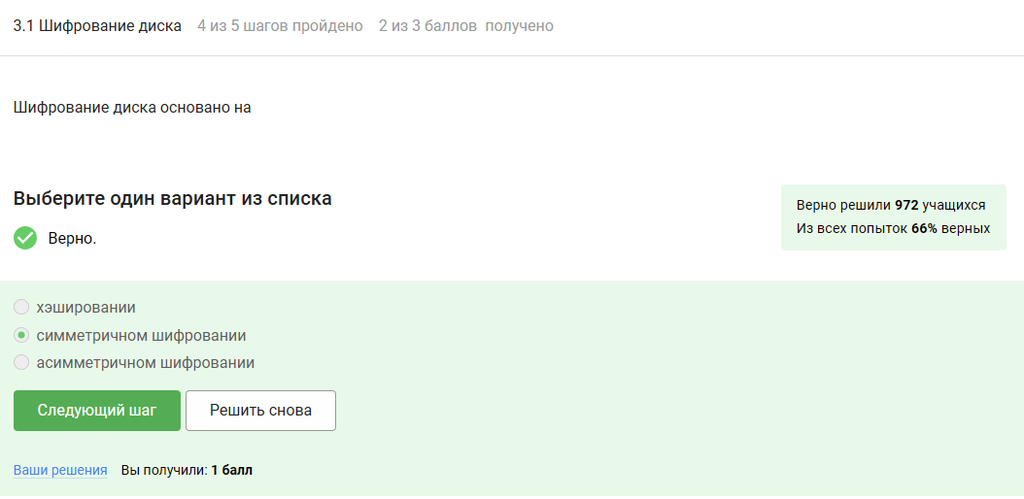

Вопрос 3.1.2

## Шифрование диска

Отмечены программы, с помощью которых можно зашифровать жетский диск.

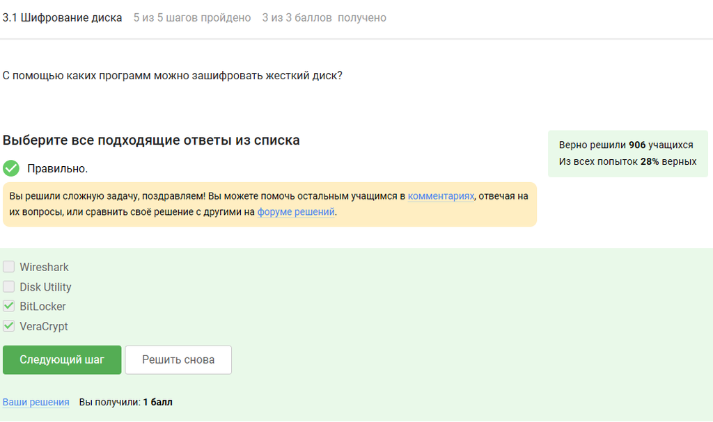

Вопрос 3.1.3

## Пароли

Стойкий пароль - тот, который тяжлее подобрать, он должен быть со спец. символами и длинный.

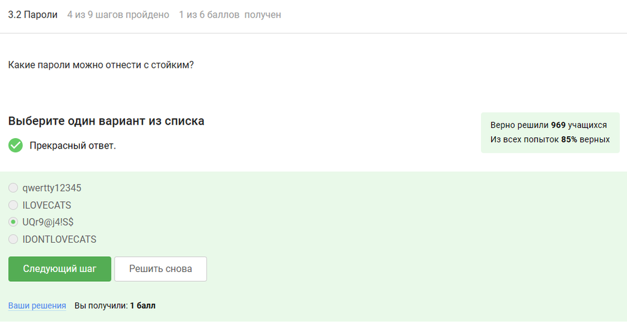

Вопрос 3.2.1

## Пароли

Все варианты, кроме менеджера паролей, совершенно не надежные.

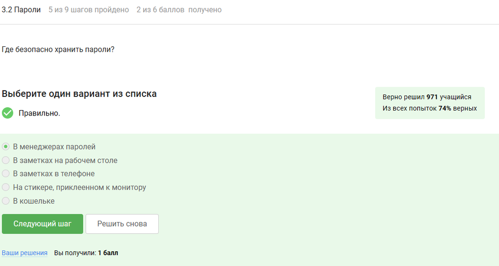

Вопрос 3.2.2

## Пароли

Капча нужна для проверки на то, что за экраном “не робот”.

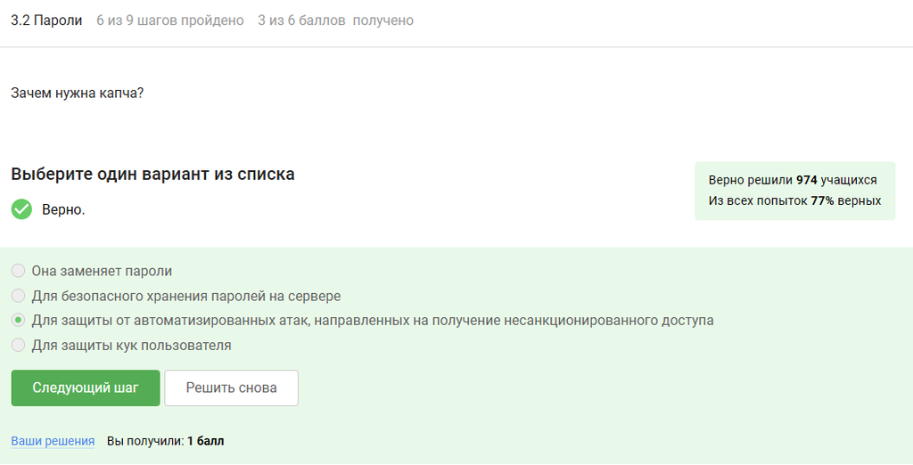

Вопрос 3.2.3

## Пароли

Опасно хранить пароли в открытом виде, поэтому хранят их хэши.

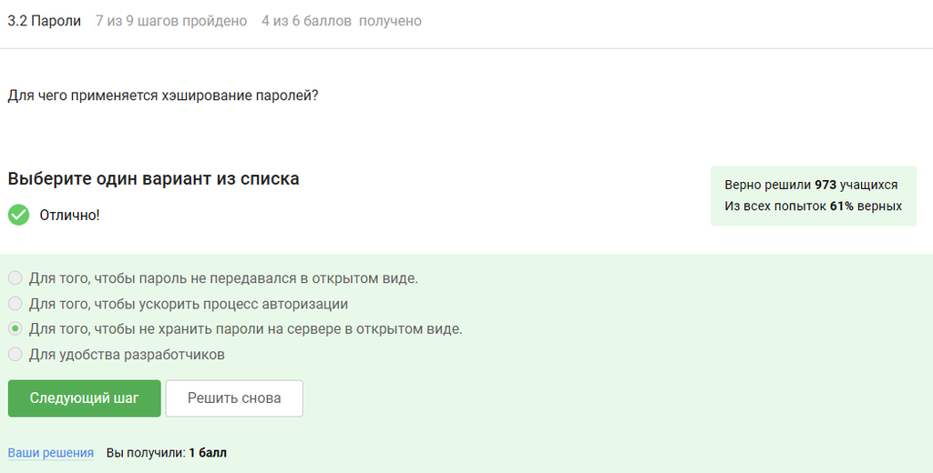

Вопрос 3.2.4

## Пароли

Соль не поможет.

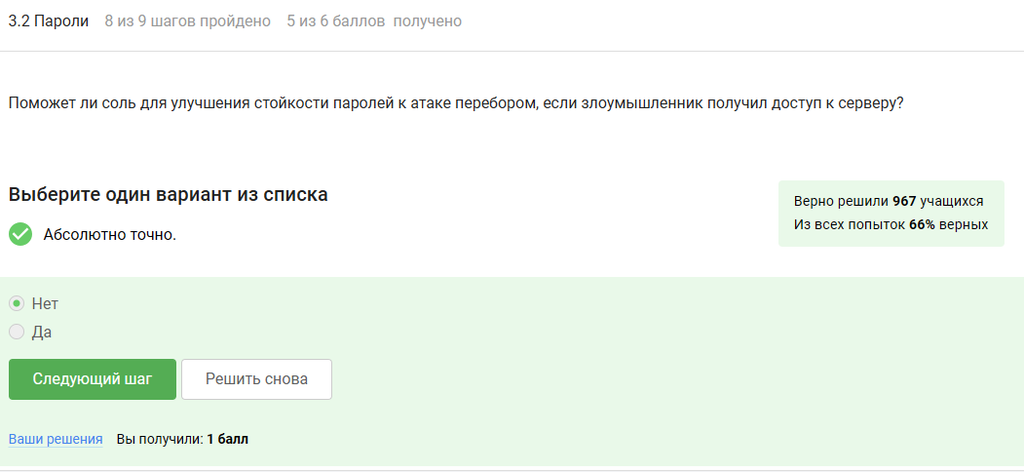

Вопрос 3.2.5

## Пароли

Все приведенные меры защищают от утечек данных.

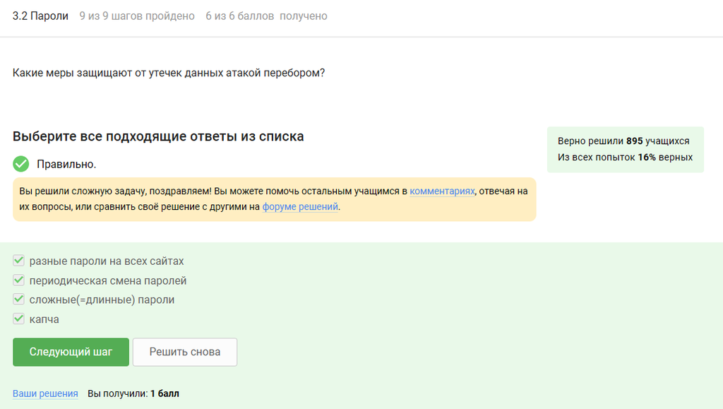

Вопрос 3.2.6

## Фишинг

Фишинговые ссылки очень похожи на ссылки известных сервисов, но с некоторыми отличиями.

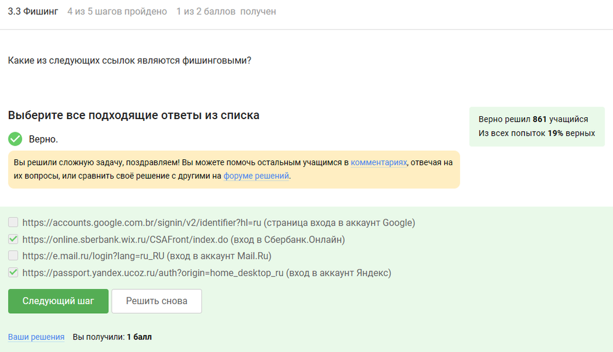

Вопрос 3.3.1

## Фишинг

Да, может, например, если пользователя со знакомым адресом взломали.

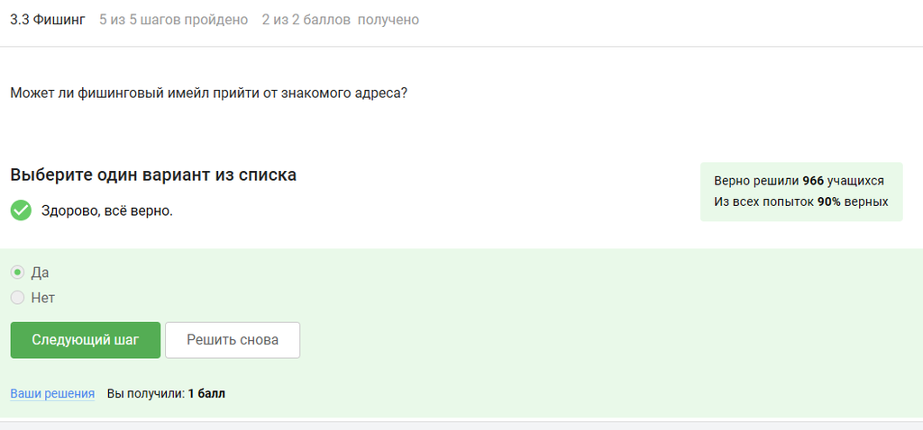

Вопрос 3.3.2

## Вирусы. Примеры

Ответ дан в соответствии с определением.

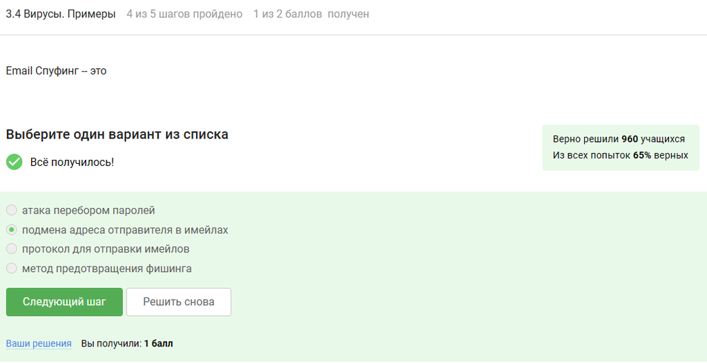

Вопрос 3.4.1

## Вирусы. Примеры

Троян маскируется под обычную программу.

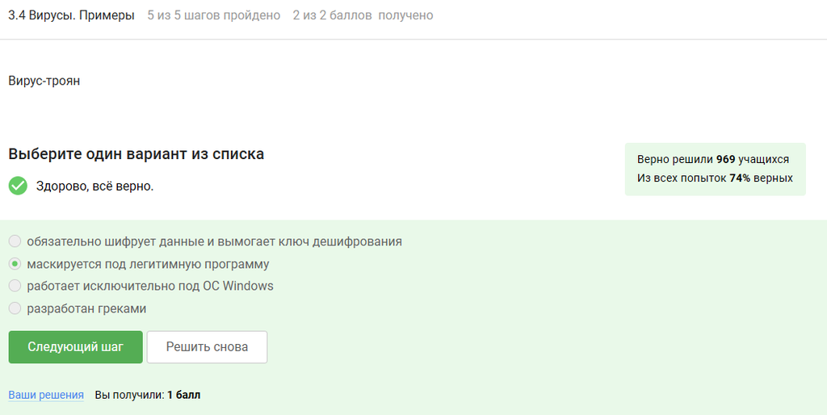

Вопрос 3.4.2

## Безопасность мессенджеров

При установке первого сообщения отправителем формируется ключ шифрования.

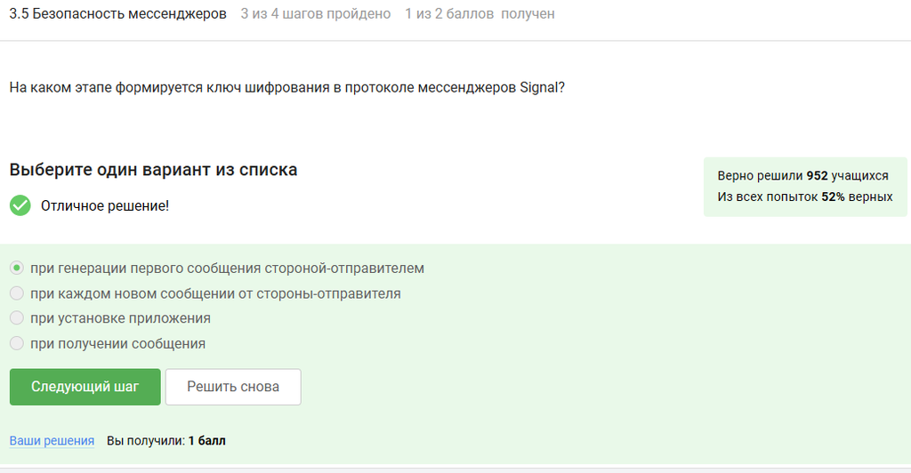

Вопрос 3.5.1

## Безопасность мессенджеров

Суть сквозного шифрования состоит в том, что сообзения передаются по узлам связи в зашифрованном виде.

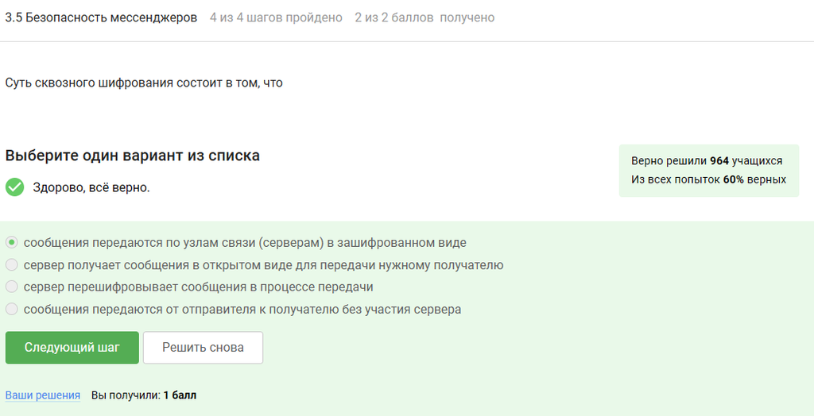

Вопрос 3.5.2

## Выводы

Был пройден второй блок курса “Основы кибербезопасности”, мной были изучены правила хранения паролей и основная информация о вирусах